# Udacity Data Analyst Nanodegree

# P1 - Titanic Data Analysis

# Introduction:

The sinking of the RMS Titanic is one of the most infamous shipwrecks in history. On April 15, 1912, during her maiden voyage, the Titanic sank after colliding with an iceberg, killing 1502 out of 2224 passengers and crew. This sensational tragedy shocked the international community and led to better safety regulations for ships.

In this data analysis exercise, I try to perform a typical data analysis starting with data wrangling, performing exploratory analysis and a coming to a conclusion to answer a set of pre-determined questions. For data wrangling, I would examine the overall dataset using standard statistical measures such as the number of features, their types (whether numeric or categorical) and metrics such as averages, medians, quantiles, min/max values etc. I would also check a crossection of data to take a look at the values of different features. I would then try to fill the NULLs using an intuitive value, categorize variables into smaller number of groups if required. For data analysis I would try to answer a few fundamental questions, in this case the survival rate of passengers and the factors affecting that. I would analyze gender, age, family sizes, passenger classes and fare spent and try to answer the question.

## 1: Data load and check

Import the necessary libraries and load the csv file in a pandas data frame and print a portion of the data.

```python
import unicodecsv as uc
import numpy as np
import pandas as pd
```

```python
file_nm = 'titanic-data.csv'
titanic_data = pd.read_csv(file_nm)
titanic_data.info();
```

```
<class 'pandas.core.frame.DataFrame'>
RangeIndex: 891 entries, 0 to 890
Data columns (total 12 columns):
PassengerId    891 non-null int64
Survived       891 non-null int64
Pclass         891 non-null int64
Name           891 non-null object
Sex            891 non-null object
Age            714 non-null float64
SibSp          891 non-null int64
Parch          891 non-null int64
Ticket         891 non-null object
Fare           891 non-null float64
Cabin          204 non-null object
Embarked       889 non-null object
dtypes: float64(2), int64(5), object(5)
memory usage: 83.6+ KB
```

It can be seen that PassengerId, Survived, PClass, SubSp, Parch are int64. Survived and PClass or passenger class are categorical variables. SibSp and Parch show the number of siblings/spouse and parent/child relationships for each traveller. Fare and Age are float64. Rest of the data is in string format, among them the Embarked and Sex variables can be categorical variables as they can take a limited set of values.

And here is the sample data:

```python
titanic_data.head(10)
```

|  | PassengerId | Survived | Pclass | Name | Sex | Age | SibSp | Parch | Ticket | Fare | Cabin | Embarked |
| --- | --- | --- | --- | --- | --- | --- | --- | --- | --- | --- | --- | --- |
| 0 | 1 | 0 | 3 | Braund, Mr. Owen Harris | male | 22.0 | 1 | 0 | A/5 21171 | 7.2500 | NaN | S |
| 1 | 2 | 1 | 1 | Cumings, Mrs. John Bradley (Florence Briggs Th... | female | 38.0 | 1 | 0 | PC 17599 | 71.2833 | C85 | C |
| 2 | 3 | 1 | 3 | Heikkinen, Miss. Laina | female | 26.0 | 0 | 0 | STON/O2. 3101282 | 7.9250 | NaN | S |
| 3 | 4 | 1 | 1 | Futrelle, Mrs. Jacques Heath (Lily May Peel) | female | 35.0 | 1 | 0 | 113803 | 53.1000 | C123 | S |
| 4 | 5 | 0 | 3 | Allen, Mr. William Henry | male | 35.0 | 0 | 0 | 373450 | 8.0500 | NaN | S |
| 5 | 6 | 0 | 3 | Moran, Mr. James | male | NaN | 0 | 0 | 330877 | 8.4583 | NaN | Q |
| 6 | 7 | 0 | 1 | McCarthy, Mr. Timothy J | male | 54.0 | 0 | 0 | 17463 | 51.8625 | E46 | S |
| 7 | 8 | 0 | 3 | Palsson, Master. Gosta Leonard | male | 2.0 | 3 | 1 | 349909 | 21.0750 | NaN | S |
| 8 | 9 | 1 | 3 | Johnson, Mrs. Oscar W (Elisabeth Vilhelmina Berg) | female | 27.0 | 0 | 2 | 347742 | 11.1333 | NaN | S |
| 9 | 10 | 1 | 2 | Nasser, Mrs. Nicholas (Adele Achem) | female | 14.0 | 1 | 0 | 237736 | 30.0708 | NaN | C |

## 2 The Questions to be Answered:

**What are the important factors behind the survival of a person in the ship, based on the data available?**

**Do age, gender, social status (based on passenger class) or the fact that there are more relatives present to help each other play a role in the survival of a person?**

## 3: Data Wrangling:

In this section I try to investigate the data set to see if there is scope for cleaning or updating the data to minimize errors in analysis and conclusions.

```python
titanic_data.describe()
```

|  | PassengerId | Survived | Pclass | Age | SibSp | Parch | Fare |
| --- | --- | --- | --- | --- | --- | --- | --- |
| count | 891.000000 | 891.000000 | 891.000000 | 714.000000 | 891.000000 | 891.000000 | 891.000000 |
| mean | 446.000000 | 0.383838 | 2.308642 | 29.699118 | 0.523008 | 0.381594 | 32.204208 |
| std | 257.353842 | 0.486592 | 0.836071 | 14.526497 | 1.102743 | 0.806057 | 49.693429 |
| min | 1.000000 | 0.000000 | 1.000000 | 0.420000 | 0.000000 | 0.000000 | 0.000000 |
| 25% | 223.500000 | 0.000000 | 2.000000 | 20.125000 | 0.000000 | 0.000000 | 7.910400 |
| 50% | 446.000000 | 0.000000 | 3.000000 | 28.000000 | 0.000000 | 0.000000 | 14.454200 |
| 75% | 668.500000 | 1.000000 | 3.000000 | 38.000000 | 1.000000 | 0.000000 | 31.000000 |
| max | 891.000000 | 1.000000 | 3.000000 | 80.000000 | 8.000000 | 6.000000 | 512.329200 |

The describe function shows the summary statistics for the numberical vaiables. The mean for Survived is < 0.5 which shows that most passengers didn't survive. As specified earlier, although Sex and Embarked are categorical but not numerical hence their statistics couldn't be obtained. I'll now convert them using the following rules: For Sex: Let 0=male and 1=female For Embarked Let 0=Cherbourg; 1=Queenstown; 2=Southampton

```python
#Converting Sex
titanic_data['Gender'] = titanic_data['Sex'].apply(lambda x: 1 if x=='female' else 0)
```

```python
#Converting Embarked
titanic_data['Embarked_int']=titanic_data['Embarked'].apply(lambda x: 0 if x=='C' else 1 if x=='Q' else 2)
```

```
* Average of all ages
* Median of all ages
* Fill random values based on the provided ages
* Mean or Median of particular group to which the person with a NaN belongs
```

Since Median is more robust measure of centrality, I'll consider median as the best option. We can create 6 groups based on Passenger Class and Gender (3 * 2), and assign the median of these 6 groups to the NaNs belonging to respective groups. Now to convert NaNs for the Age variable, I will create an array called median_ages and fill the medians based on Gender and PClass variables as shown below. Next I'll create an additional column and fill the NaNs values.

```python
titanic_data['AgeNaN']=titanic_data['Age']
titanic_data.loc[:,'AgeNaN'] = titanic_data.groupby(['Gender','Pclass']).transform(lambda x: x.fillna(x.median()))
```

```python
titanic_data.describe()
```

|  | PassengerId | Survived | Pclass | Age | SibSp | Parch | Fare | Gender | Embarked_int | AgeNaN |
| --- | --- | --- | --- | --- | --- | --- | --- | --- | --- | --- |
| count | 891.000000 | 891.000000 | 891.000000 | 714.000000 | 891.000000 | 891.000000 | 891.000000 | 891.000000 | 891.000000 | 891.000000 |
| mean | 446.000000 | 0.383838 | 2.308642 | 29.699118 | 0.523008 | 0.381594 | 32.204208 | 0.352413 | 1.536476 | 29.112424 |
| std | 257.353842 | 0.486592 | 0.836071 | 14.526497 | 1.102743 | 0.806057 | 49.693429 | 0.477990 | 0.791503 | 13.304424 |
| min | 1.000000 | 0.000000 | 1.000000 | 0.420000 | 0.000000 | 0.000000 | 0.000000 | 0.000000 | 0.000000 | 0.420000 |
| 25% | 223.500000 | 0.000000 | 2.000000 | 20.125000 | 0.000000 | 0.000000 | 7.910400 | 0.000000 | 1.000000 | 21.500000 |
| 50% | 446.000000 | 0.000000 | 3.000000 | 28.000000 | 0.000000 | 0.000000 | 14.454200 | 0.000000 | 2.000000 | 26.000000 |
| 75% | 668.500000 | 1.000000 | 3.000000 | 38.000000 | 1.000000 | 0.000000 | 31.000000 | 1.000000 | 2.000000 | 36.000000 |
| max | 891.000000 | 1.000000 | 3.000000 | 80.000000 | 8.000000 | 6.000000 | 512.329200 | 1.000000 | 2.000000 | 80.000000 |

Now we would drop some of the columns that won't be helpful in analysis. The columns are PassengerID, Name, Ticket, Sex and Embarked. The field Cabin also doesn't seem to have an important impact as it has a lot of NaN values which can't be filled easily. So we have Class, Age, Family, Fare, Gender and Embarked port information to use to answer the questions.

```python
titanic_data = titanic_data.drop(['PassengerId','Name','Ticket', 'Sex', 'Embarked', 'Cabin'], axis=1)
titanic_data.describe()
```

|  | Survived | Pclass | Age | SibSp | Parch | Fare | Gender | Embarked_int | AgeNaN |
| --- | --- | --- | --- | --- | --- | --- | --- | --- | --- |
| count | 891.000000 | 891.000000 | 714.000000 | 891.000000 | 891.000000 | 891.000000 | 891.000000 | 891.000000 | 891.000000 |
| mean | 0.383838 | 2.308642 | 29.699118 | 0.523008 | 0.381594 | 32.204208 | 0.352413 | 1.536476 | 29.112424 |
| std | 0.486592 | 0.836071 | 14.526497 | 1.102743 | 0.806057 | 49.693429 | 0.477990 | 0.791503 | 13.304424 |
| min | 0.000000 | 1.000000 | 0.420000 | 0.000000 | 0.000000 | 0.000000 | 0.000000 | 0.000000 | 0.420000 |
| 25% | 0.000000 | 2.000000 | 20.125000 | 0.000000 | 0.000000 | 7.910400 | 0.000000 | 1.000000 | 21.500000 |
| 50% | 0.000000 | 3.000000 | 28.000000 | 0.000000 | 0.000000 | 14.454200 | 0.000000 | 2.000000 | 26.000000 |
| 75% | 1.000000 | 3.000000 | 38.000000 | 1.000000 | 0.000000 | 31.000000 | 1.000000 | 2.000000 | 36.000000 |
| max | 1.000000 | 3.000000 | 80.000000 | 8.000000 | 6.000000 | 512.329200 | 1.000000 | 2.000000 | 80.000000 |

## 4: Data Exploration

#### 4.1 Correlations

```python
def survive_corr(col):
    """ Checking the survival correlations """
    corr = titanic_data[col].corr(titanic_data['Survived'])
    return pd.Series(corr, index=[col])

age_corr = survive_corr ('Age')
gender_corr = survive_corr ('Gender')
par_corr = survive_corr ('Parch')
sib_corr = survive_corr ('SibSp')
class_corr = survive_corr ('Pclass')
fare_corr = survive_corr('Fare')

corr_vector = [age_corr, gender_corr, par_corr, sib_corr, class_corr, fare_corr]
corr_vector
```

```
[Age   -0.077221
 dtype: float64, Gender    0.543351
 dtype: float64, Parch    0.081629
 dtype: float64, SibSp   -0.035322
 dtype: float64, Pclass   -0.338481
 dtype: float64, Fare    0.257307
 dtype: float64]
```

As shown above the variables showing a considerable correlation, compared to others, with Survived are Gender, Pclass and Fare. Although the correlation isn't very high but, Gender is still the highest. Since Female was designated 1, hence it shows Survival is leaning towrds female. On the other hand, with PClass the correlation is negative, this is because the higher class, 1 has a least absolute values, hence there is some leaning of Survivability towards better passenger class. The Fare is slightly lower than Pclass in correlation but shows a positive correlation showing that a higher fare paying passenger had a better chance of survival. I will be using Statistical tests in sub-sections of Gender, Family Size, Age, Passenger Class and Fare analysis below. I will convert Age and Fare to an ordinal variables for better analysis and use Chi-Square tests of independence to check relationships between the 3 variables and Survival.

#### 4.2 Gender

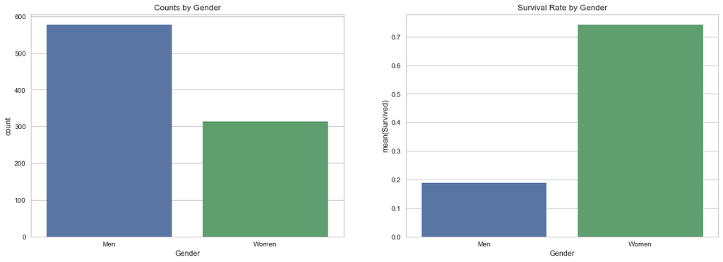

```python
import seaborn as sns
import matplotlib.pyplot as plt
sns.set_style('whitegrid')
%matplotlib inline

#Gender Analysis
fig, (axis1,axis2) = plt.subplots(1,2,figsize=(18,6))
sns_plt0=sns.countplot(x='Gender', data=titanic_data, ax=axis1)
sns_plt0.set_xticklabels(['Men','Women'])
sns_plt0.set_title("Counts by Gender");
gender_perc = titanic_data[["Gender", "Survived"]].groupby(['Gender'],as_index=False).mean()
gender_perc
sns_plt = sns.barplot(x='Gender', y='Survived', data=gender_perc, ax=axis2)
sns_plt.set_xticklabels(['Men', 'Women']);
sns_plt.set_title("Survival Rate by Gender");
```

The plots above show that although there were fewer women on Titanic, the chance of survival was much better for Women.

##### 4.2.1 Statistical Test

I performed the Chi-Square statistical test to verify the survival rate differences based on Gender: H0 - The survival rates of population means of Females is same as that of Males OR

```
      µf = µm
```

Ha - The survival rate of population means of Females and Males are different

```
      µf ≠ µm
```

where µf is the population mean of female survived and µm is the population mean of male survived.

```python
from scipy.stats import chi2_contingency
chi2_contingency(pd.crosstab(titanic_data.Survived, titanic_data.Gender))
```

```
(260.71702016732104,
 1.1973570627755645e-58,
 1L,
 array([[ 355.52525253,  193.47474747],
        [ 221.47474747,  120.52525253]]))
```

The p-value is negligible (1.1973570627755645e-58) and hence the H0 can be rejected. We can say with 95% of confidence that mean survival rate of Females is greater than that of Males.

#### 4.3 Parch/SibSp - Family

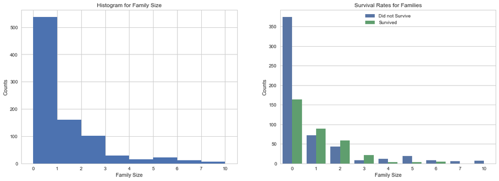

```python
titanic_data['Family']=titanic_data['Parch'] + titanic_data['SibSp']
fig, (axis1,axis2) = plt.subplots(1,2,sharex=True,figsize=(18,6))
axis1.set_title('Histogram for Family Size')
axis1.set(ylabel="Counts", xlabel="Family Size");
titanic_data['Family'].hist(bins=10, ax=axis1)

axis2.set_title('Survival Rates for Families')
sns_plt1=sns.countplot(x='Family',hue='Survived', data=titanic_data)
axis2.legend(['Did not Survive', 'Survived'])
axis2.set(ylabel="Counts", xlabel="Family Size");
```

Since Parch and SibSp if combined together would show how many family members did a passenger have, I think it would be better to work with the family member count rather than just parents and siblings independently. Hence I created a new variable Family by summing up the two.

The first plot above shows that most people (greater than 500) didn't have a family member on board. There is almost an exponential decline in the number of passenger having a family member with them. The second plot breaks down the first into survived and non-survived passenger category. It can be clearly seen that as family members rise to a limit of 3, i.e. a family of 2 to 4 members showed a better survival rate. After the size of 4, family again shows a decline in survival rate and most of them not being able to survive.

##### 4.3.1 Statistical Test

I divided the Familiy variable (which has 9 categories based on family size) into 3 groups as explained below and performed the Chi-Square test:

H0 - The population mean of survived passengers among all family groups is same

```
      µs = µsf = µlf
```

Ha - The population mean of survived passengers among at least 2 family groups is not same

```
      µs ≠ µsf ≠ µlf
```

where :

```
  µs is the population mean of single members who survived and

  µsf is the population mean of families which are small ranging from 2 to 4 members and

  µlf is the population mean of families of size greater than 4.
```

```python
titanic_data['Family_Grp']=titanic_data['Family'].apply(lambda x: 'Single' if x==0 else 'Small' \
                                                          if (x>=1 and x<=3) else 'Large')
from scipy.stats import chi2_contingency
chi2_contingency(pd.crosstab(titanic_data.Survived, titanic_data.Family_Grp))
```

```
(74.537249046982396,
 6.5229195366404726e-17,
 2L,
 array([[  38.2020202 ,  330.87878788,  179.91919192],
        [  23.7979798 ,  206.12121212,  112.08080808]]))
```

The p-value is very small at (6.5229195366404726e-17) and hence the H0 hypothesis can be rejected with 95% confidence. And we can say that mean survival for the 3 family groups is not the same.

#### 4.4 Age

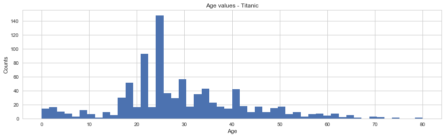

```python
# plot Age values
fig, axis1 = plt.subplots(1, figsize=(15,4))
axis1.set_title('Age values - Titanic')
titanic_data['AgeNaN'].astype(int).hist(bins=50, ax=axis1)
axis1.set_ylabel('Counts');
axis1.set_xlabel('Age');
```

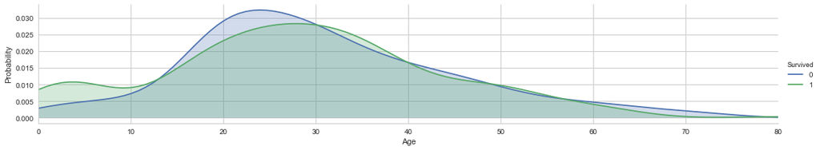

```python
# peaks for survived/not survived passengers by their age
#fig, axis1 = plt.subplots(1, figsize=(15,4))
facet = sns.FacetGrid(titanic_data, hue="Survived",aspect=5)
facet.map(sns.kdeplot,'Age',shade= True)
facet.set(xlim=(0, titanic_data['Age'].max()))
facet.set_axis_labels("Age", "Probability")
facet.set_titles("Survival Probability by Age")
facet.add_legend();
```

The age histogram shows that most of the passengers are in the 20-40 years age range.

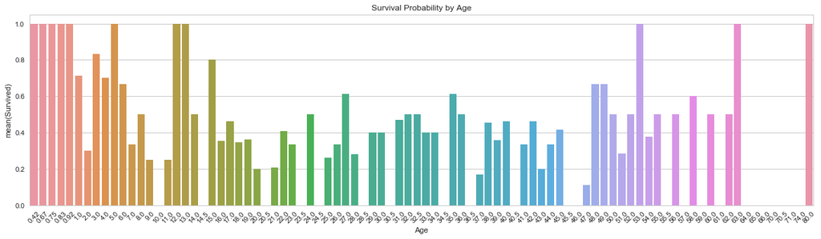

```python
# average survived passengers by age
fig, axis1 = plt.subplots(1,1,figsize=(20,5))
age_survived = titanic_data[["Age", "Survived"]].groupby(['Age'],as_index=False).mean()
sns_plt2=sns.barplot(x='Age', y='Survived', data=age_survived)
sns_plt2.set_xticklabels(age_survived['Age'], rotation=45);
sns_plt2.set_title("Survival Probability by Age");
```

The plot above shows the age distribution along with survival rate for the given age. And as iterated earlier the plot shows a very high survival chance for childern in 0-10 range. The survival rate is low for mid age range, which consists of the most the number passengers also.

##### 4.4.1 Statistical Test

I performed the Chi-Square statistical test to verify the survival rate differences based on Age: H0 - The population means of survived Children (under the age of 10) is same as that of Adults OR

```
      µc = µa
```

Ha - The population means of survived Children and Adults are different

```
      µc ≠ µa
```

where µc is the population mean of Children (under the age of 10) survived and µa is the population mean of Adults survived.

```python
titanic_data['Age_Grp']=titanic_data['Age'].apply(lambda x: 'Child' if x<10 else 'Adult')
from scipy.stats import chi2_contingency
chi2_contingency(pd.crosstab(titanic_data.Survived, titanic_data.Age_Grp))
```

```
(13.761242516444689,
 0.00020757475971630712,
 1L,
 array([[ 510.7979798,   38.2020202],
        [ 318.2020202,   23.7979798]]))
```

The p-value is very small at (0.000207) and hence the H0 hypothesis can be rejected with 95% confidence. And we can say that mean survival for the Children is greater than that of Adults.

#### 4.5 Fare and Passenger Class

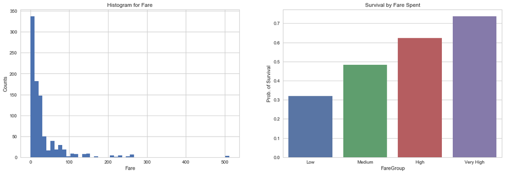

```python
from pandas import Series,DataFrame

#titanic_data['Fare'].plot(kind='hist', bins=100, xlim=(0,300),figsize=(9,5))

fig, (axis1,axis2) = plt.subplots(1,2,figsize=(19,6))
axis1.set_title('Histogram for Fare')
axis1.set(ylabel="Counts", xlabel="Fare");
titanic_data['Fare'].hist(bins=50, ax=axis1)
#sns_plt3=sns.countplot(x='Fare',hue='Survived', data=titanic_data, ax=axis2)
titanic_data['FareGroup'] = pd.cut(titanic_data['Fare'], bins=[0,30,60,100,600], \
                                   labels=['Low','Medium','High', 'Very High'])
sns.barplot(x="FareGroup", y="Survived", data=titanic_data,ci=None, ax=axis2)
plt.title('Survival by Fare Spent')
plt.ylabel('Prob. of Survival')
plt.show();
```

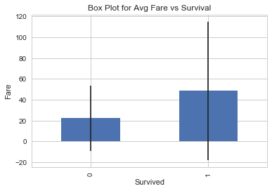

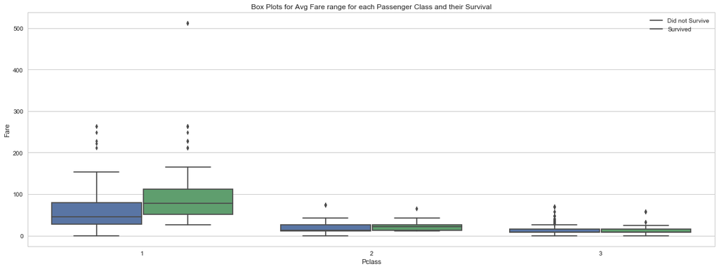

```python
# Fare for Survived and non-Survived
fare_sur   = titanic_data["Fare"][titanic_data["Survived"] == 1]
fare_x_sur = titanic_data["Fare"][titanic_data["Survived"] == 0]

#Averages
avg_fare = DataFrame([fare_x_sur.mean(), fare_sur.mean()])
std_fare = DataFrame([fare_x_sur.std(), fare_sur.std()])

avg_fare.index.names = std_fare.index.names = ["Survived"]
bx_plt=avg_fare.plot(yerr=std_fare,kind='bar',legend=False)
bx_plt.set_title("Box Plot for Avg Fare vs Survival")
bx_plt.set_ylabel('Fare')
#plt.setp(xticknames)

fig, axis1 = plt.subplots(1,1,figsize=(20,7))
sns.boxplot(x="Pclass", y="Fare", hue='Survived', data=titanic_data)
axis1.legend(['Did not Survive','Survived'])
axis1.set_title('Box Plots for Avg Fare range for each Passenger Class and their Survival');
```

##### 4.5.1 Statsitical Test

##### Fare Group

Based on the 4 Fare Groups shown above in the bar chart, I conduct the following hypothesis test :

H0 - The population mean of survived passengers among Fare 4 groups is same and Survival is independent of Fare

```
µl = µm = µh = µvh
```

Ha - The popluation mean of survived passengers among Fare 4 groups are different and Surivival is dependent on Fare

```
µl ≠ µm ≠ µh ≠ µvh
```

where:

µl, µm, µh, µvh are population means for Low Fare, Medium Fare, High Fare and Very High Fare respectively.

```python
from scipy.stats import chi2_contingency
chi2_contingency(pd.crosstab(titanic_data.Survived, titanic_data.FareGroup))
```

```
(59.937909915848664,
 6.0605444243610758e-13,
 3L,
 array([[ 392.0890411 ,   68.40182648,   42.14041096,   32.36872146],
        [ 249.9109589 ,   43.59817352,   26.85958904,   20.63127854]]))
```

The p-value from the above test is very small (6.0605444243610758e-13) and hence I reject the null hypothesis. We can say with a 95% confidence that Survival is dependent on Fare Groups as I have defined them and the population means differ for different Fare Groups.

##### Passenger Class

H0 - The population mean of survived passengers among 3 Passenger Classes is same and Survival is independent of Passenger Class

```
µ1 = µ2 = µ3
```

Ha - The popluation mean of survived passengers among 3 Passenger Classes are different and Surivival is dependent on Passenger Class

```
µ1 ≠ µ2 ≠ µ3
```

where:

µ1, µ2, µ3 are population means for Passenger Classes 1, 2 and 3 respectively.

```python
from scipy.stats import chi2_contingency
chi2_contingency(pd.crosstab(titanic_data.Survived, titanic_data.Pclass))
```

```
(102.88898875696056,
 4.5492517112987927e-23,
 2L,
 array([[ 133.09090909,  113.37373737,  302.53535354],
        [  82.90909091,   70.62626263,  188.46464646]]))
```

The p-value from the above test is very small (4.5492517112987927e-23) and hence I reject the null hypothesis. We can say with a 95% confidence that Survival is dependent on Passenger Class and the population means differ for different classes.

## 5: Conclusion

Based on the analysis, the survival rate for Women and Children is found to be high. Same can be said for the families of medium size. The survival rate was also high for higher paying class 1 passengers. I have conducted statistical analysis to verify these findings although these relations don't lead to causation.

Although since there are many missing aspects that could contribute to the accuracy of this analysis. As we know that sinking of the Titanic killed 1502 out of 2224 passengers and crew, while this data set has only 891 values. So we are working with only 40% of the data. Any inferences from this limited data have to be digested with an understanding that we are not seeing the complete picture but just a part of it. Another exmaple is the case of Age variable as there were more than 170 missing values, recorded as NaNs which is almost 20% of the entire dataset. Probably having those values could lead to more robust conclusions when it comes to survival analysis by age. A feature that could have helped the investigation better would be the location of different people in the ship. The variable Cabin could be of help if each cabin could be mapped and distance from the nearest escape point could be determined and used for our analysis. This could help us understand how far they were from available help and while the ship was sinking.

## Appendix:

#### Data

VARIABLE DESCRIPTIONS: survival Survival (0 = No; 1 = Yes) pclass Passenger Class (1 = 1st; 2 = 2nd; 3 = 3rd) name Name sex Sex age Age sibsp Number of Siblings/Spouses Aboard parch Number of Parents/Children Aboard ticket Ticket Number fare Passenger Fare cabin Cabin embarked Port of Embarkation (C = Cherbourg; Q = Queenstown; S = Southampton)

SPECIAL NOTES: Pclass is a proxy for socio-economic status (SES) 1st ~ Upper; 2nd ~ Middle; 3rd ~ Lower

Age is in Years; Fractional if Age less than One (1) If the Age is Estimated, it is in the form xx.5

With respect to the family relation variables (i.e. sibsp and parch) some relations were ignored. The following are the definitions used for sibsp and parch.

Sibling: Brother, Sister, Stepbrother, or Stepsister of Passenger Aboard Titanic Spouse: Husband or Wife of Passenger Aboard Titanic (Mistresses and Fiances Ignored) Parent: Mother or Father of Passenger Aboard Titanic Child: Son, Daughter, Stepson, or Stepdaughter of Passenger Aboard Titanic

Other family relatives excluded from this study include cousins, nephews/nieces, aunts/uncles, and in-laws. Some children travelled only with a nanny, therefore parch=0 for them. As well, some travelled with very close friends or neighbors in a village, however, the definitions do not support such relations.

### References

Matplotlib - http://matplotlib.org/examples/api/barchart_demo.html

Seaborn - http://seaborn.pydata.org/api.html

Kaggle - https://www.kaggle.com/c/titanic

https://www.kaggle.com/c/titanic/details/getting-started-with-python

Chi-Square - https://onlinecourses.science.psu.edu/stat500/node/56